## Waffle Chart / Square Pie Chart

The waffle package {[CRAN](https://cran.r-project.org/web/packages/waffle/waffle.pdf) and [Github](https://github.com/hrbrmstr/waffle)} creates suare pie charts. It can also be combined with [glyphs](http://fontawesome.io/) for more elegant shapes than squares. This example uses data pulled from [A Vision for an Equitable DC](http://www.urban.org/features/vision-equitable-dc).

### Single Waffle Chart

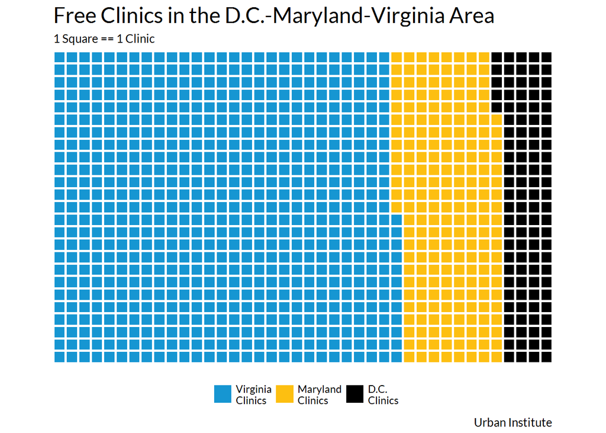

```r
library(waffle)

parts <- c(`Virginia\nClinics` = (1000 - 208 - 105), `Maryland\nClinics` = 208, `D.C.\nClinics` = 105)
waffle(parts, rows = 25, size = 1, colors = c("#1696d2", "#fdbf11", "#000000"), legend_pos = "bottom") +
  labs(title = "Free Clinics in the D.C.-Maryland-Virginia Area",
       subtitle = "1 Square == 1 Clinic",
       caption = "Urban Institute") +
  theme(text = element_text(family = "Lato"))
```

### Waffle Charts with Glyphs

Waffle charts can be enhanced by replacing squares qith glyphs. Two important arguments to know are `glyph_size =` and `use_glyph =`. Both are called in the `waffle()` function. Note: `size = 1` is sensible and `glyph_size = 12` is sensible.

[figure not shown]

```r
library(extrafont)
#font_import("H:/IT/urban_R_theme/docs")
#loadfonts()

parts <- c(`Virginia\nClinics` = (50 - 10 - 5), `Maryland\nClinics` = 10, `D.C.\nClinics` = 5)
waffle(parts, rows = 5, glyph_size = 12, colors = c("#1696d2", "#fdbf11", "#000000"), legend_pos = "bottom", use_glyph = "medkit") +
  labs(title = "Free Clinics in the D.C.-Maryland-Virginia Area",
       subtitle = "1 Square == 20 Clinics",
       caption = "Urban Institute") +
  theme(text = element_text(family = "Lato"))
```

### Multiple Waffle Charts

`library(waffle)` allows multiple waffle charts to be ironed together using `iron()`. Ironing multiple charts together requires some trial-and-error to get the sizes and resolution to look good, but the results can be worth the work. Don’t forget `theme(text = element_text(family = "Lato"))`!

```r
library(waffle)

white <- c(`With Degree` = 169300, `Without Degree` = 800)
black <- c(`With Degree` = 174900, `Without Degree` = 34700)
hispanic <- c(`With Degree` = 27700, `Without Degree` = 12400)

iron(
  waffle(white / 83, rows = 40, size = 0.25, colors = c("#1696d2", "#fdbf11"), title = "White", keep = FALSE, pad = 10) +
  theme(text = element_text(family = "Lato")),
  waffle(black / 83, rows = 40, size = 0.25, colors = c("#1696d2", "#fdbf11"), title = "Black", keep = FALSE) +
  theme(text = element_text(family = "Lato")),
  waffle(hispanic / 83, rows = 40, size = 0.25, colors = c("#1696d2", "#fdbf11"), title = "Hispanic", keep = FALSE, pad = 59, xlab = "1 Square == 83 People") +
  theme(text = element_text(family = "Lato"))
)
```

[figure not shown]

## Heat map

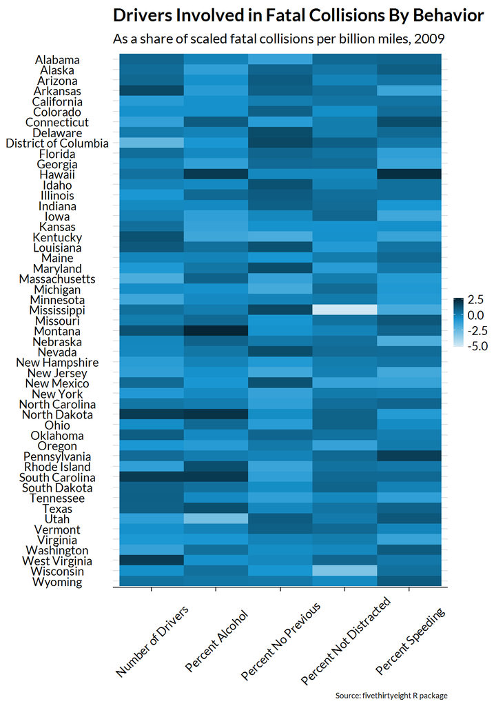

```r
library(fivethirtyeight)

bad_drivers %>%
  mutate(`Number of Drivers` = scale(num_drivers),
         `Percent Speeding` = scale(perc_speeding),
         `Percent Alcohol` = scale(perc_alcohol),
         `Percent Not Distracted` = scale(perc_not_distracted),
         `Percent No Previous` = scale(perc_no_previous),
         state = factor(state, levels = rev(state))
         ) %>%
  select(-insurance_premiums, -losses, -(num_drivers:losses)) %>%
  gather(`Number of Drivers`:`Percent No Previous`, key = "variable", value = "SD's from Mean") %>%
  ggplot(aes(variable, state)) +
    geom_tile(aes(fill = `SD's from Mean`)) +
    labs(title = "Drivers Involved in Fatal Collisions By Behavior",
      subtitle = "As a share of scaled fatal collisions per billion miles, 2009",
      caption = "Source: fivethirtyeight R package",
      x = NULL,
      y = NULL) +
    scale_fill_gradientn() +
    theme(legend.position = "right",
      legend.direction = "vertical",
      axis.text.x = element_text(angle = 45))
```

```r
#https://learnr.wordpress.com/2010/01/26/ggplot2-quick-heatmap-plotting/
```

## Faceting and Small Multiples

### facet_wrap()

R’s faceting system is a powerful way to make “small multiples”.

Some edits to the theme may be necessary depending upon how many rows and columns are in the plot.

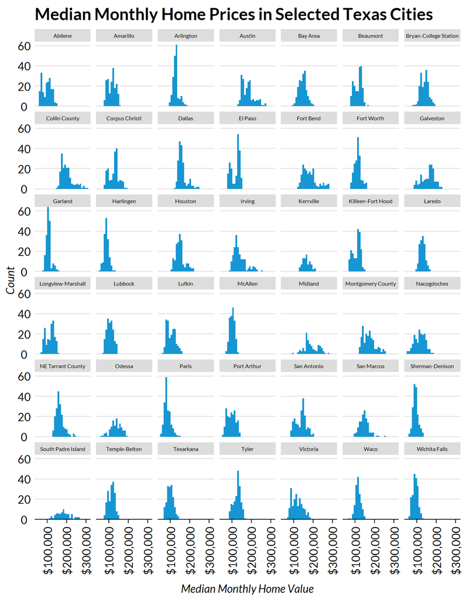

```r
# Facet Wrap
txhousing %>%
  filter(!city %in% c("Brazoria County", "Brownsville", "San Angelo", "Denton County")) %>%
  ggplot(aes(x = median)) +
  geom_histogram() +
  facet_wrap(~city) +
  scale_x_continuous(labels = scales::dollar) +
  scale_y_continuous(expand = c(0, 0)) +
  labs(title = "Median Monthly Home Prices in Selected Texas Cities",
       x = "Median Monthly Home Value",
       y = "Count") +
  theme(axis.text.x = element_text(angle = 90),
        strip.text = element_text(face = "plain",
                              size = rel(0.5)))
```

### facet_grid()

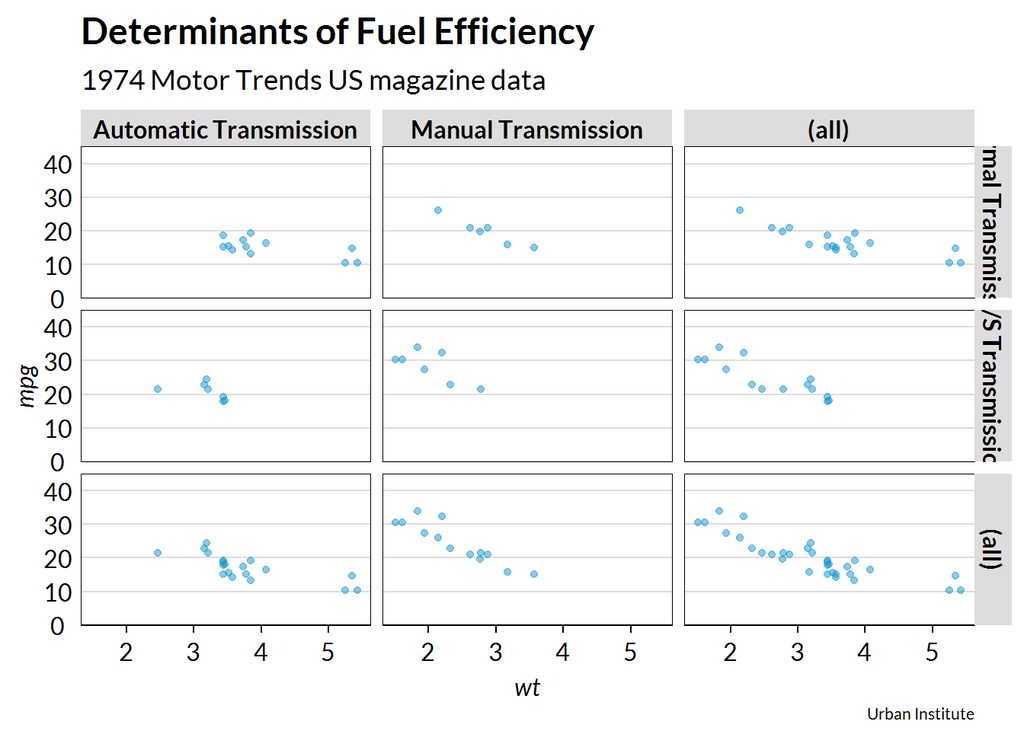

```r
## Facet Grid
mtcars %>%
    mutate(vs = factor(vs, levels = 0:1, labels = c("Normal Transmission", "V/S Transmission")),
                 am = factor(am, levels = 0:1, labels = c("Automatic Transmission", "Manual Transmission"))) %>%
    ggplot(aes(wt, mpg)) +
        geom_point(alpha = 0.5) +
        scale_y_continuous(expand = c(0, 0), limits = c(0, 45)) +
    labs(title = "Determinants of Fuel Efficiency",
             subtitle = "1974 Motor Trends US magazine data",
        caption = "Urban Institute") +
    facet_grid(vs ~ am, margins = TRUE) +
        theme(panel.border = element_rect(colour = "black", fill = NA, size = 0.3))
```

## Smoothers

`geom_smooth()` fits and plots models to data with two or more dimensions.

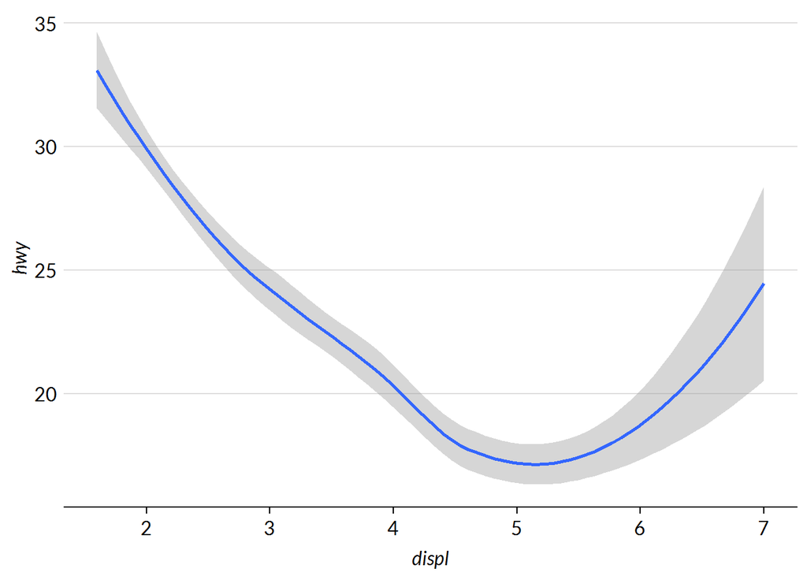

```r
ggplot(data = mpg) +
    geom_smooth(mapping = aes(x = displ, y = hwy))
```

Understanding and manipulating defaults is more important for `geom_smooth()` than other geoms because it contains a number of assumptions. `geom_smooth()` automatically uses loess for datasets with fewer than 1,000 observations and a generalized additive model with `formula = y ~ s(x, bs = "cs")` for datasets with greater than 1,000 observations. Both default to a 95% confidence interval with the confidence interval displayed.

Models are chosen with `method =` and can be set to lm(), glm(), gam(), loess(), rlm(), and more. Formulas can be specified with `formula =` and `y ~ x` syntax. Plotting the standard error is toggled with `se = TRUE` and `se = FALSE`, and level is specificed with `level =`. As always, more information can be seen in RStudio with `?geom_smooth()`.

`geom_point()` adds a scatterplot to `geom_smooth()`. The order of the function calls is important. The function called second will be layed on top of the function called first.

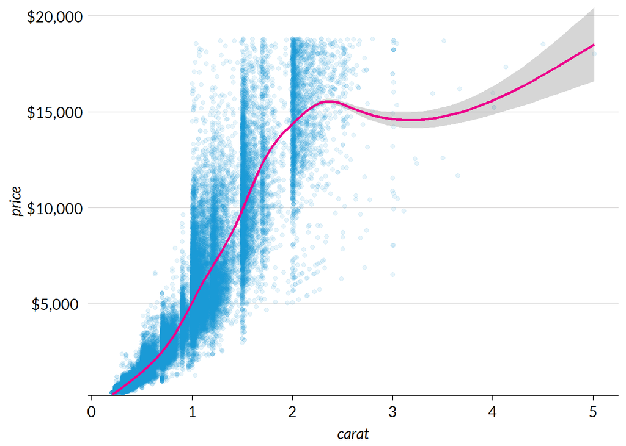

```r
ggplot(data = diamonds, mapping = aes(x = carat, y = price)) +
    geom_point(alpha = 0.1) +
    geom_smooth(color =  "#ec008b") +
    scale_y_continuous(expand = c(0, 0), labels = scales::dollar)
```

`geom_smooth` can be subset by categorical and factor variables. This requires subgroups to have a decent number of observations and and a fair amount of variability across the x-axis. Confidence intervals often widen at the ends so special care is needed for the chart to be meaningful and readable.

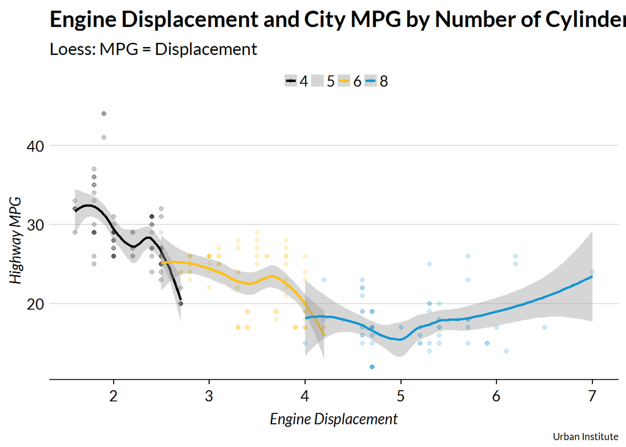

```r
ggplot(data = mpg, mapping = aes(x = displ, y = hwy, color = factor(cyl))) +
    geom_point(alpha = 0.2) +
    geom_smooth() +
    labs(title = "Engine Displacement and City MPG by Number of Cylinders",
             subtitle = "Loess: MPG = Displacement",
             caption = "Urban Institute",
             x = "Engine Displacement",
             y = "Highway MPG")
```

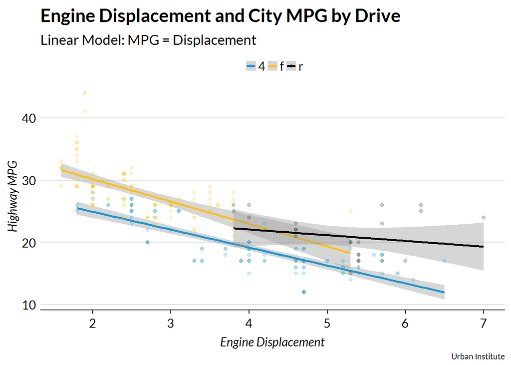

```r
ggplot(data = mpg, mapping = aes(x = displ, y = hwy, color = drv)) +
    geom_smooth(method = "lm") +
    geom_point(alpha = 0.2) +
    labs(title = "Engine Displacement and City MPG by Drive",
             subtitle = "Linear Model: MPG = Displacement",
             caption = "Urban Institute",
             x = "Engine Displacement",
             y = "Highway MPG")
```

## Text and Annotation

Several functions can be used to annotate, label, and highlight different parts of plots. `geom_text()` and `geom_text_repel()` both display variables from data frames. `annotate()`, which has several different uses, displays variables and values included in the function call.

### geom_text()

`geom_text()` turns text variables in data sets into geometric objects. This is useful for labeling data in plots. Both functions need `x` values and `y` values to determine placement on the coordinate plane, and a text vector of labels.

This can be used to label `geom_bar()`.

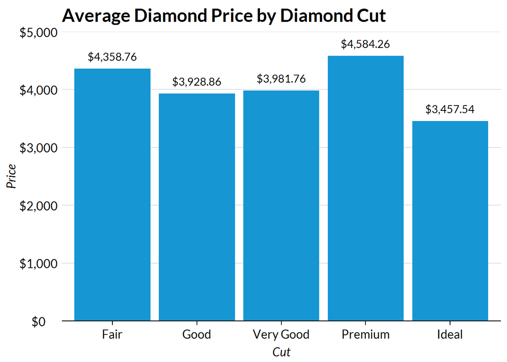

```r
diamonds %>%
  group_by(cut) %>%
  summarize(price = mean(price)) %>%
  ggplot(aes(cut, price)) +
  geom_bar(stat = "identity") +
  geom_text(aes(label = scales::dollar(price)), vjust = -1) +
  scale_y_continuous(expand = c(0, 0),
                                     labels = scales::dollar,
                     limits = c(0, 5000)) +
  labs(title = "Average Diamond Price by Diamond Cut",
       x = "Cut",
       y = "Price")
```

It can also be used to label points in a scatter plot.

It’s rarely useful to label every point in a scatter plot. Use `filter()` to create a second data set that is subsetted and pass it into the labelling function.

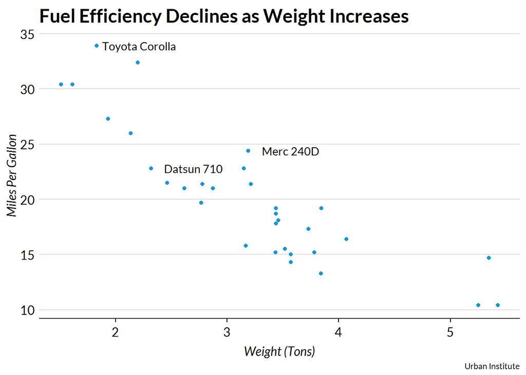

```r
labels <- mtcars %>%
    rownames_to_column("model") %>%
    filter(model %in% c("Toyota Corolla", "Merc 240D", "Datsun 710"))

mtcars %>%
    ggplot(mapping = aes(x = wt, y = mpg)) +
        geom_point() +
        geom_text(data = labels, mapping = aes(x = wt, y = mpg, label = model), nudge_x = 0.38) +
      labs(title = "Fuel Efficiency Declines as Weight Increases",
       caption = "Urban Institute",
       x = "Weight (Tons)",
       y = "Miles Per Gallon")
```

Text too often overlaps with other text or geoms when using `geom_text()`. `library(ggrepel)` is a `library(ggplot2)` add-on that automatically positions text so it doesn’t overlap with geoms or other text. To add this functionality, install and load `library(ggrepel)` and then use `geom_text_repel()` with the same syntax as `geom_text()`.

### geom_text_repel()

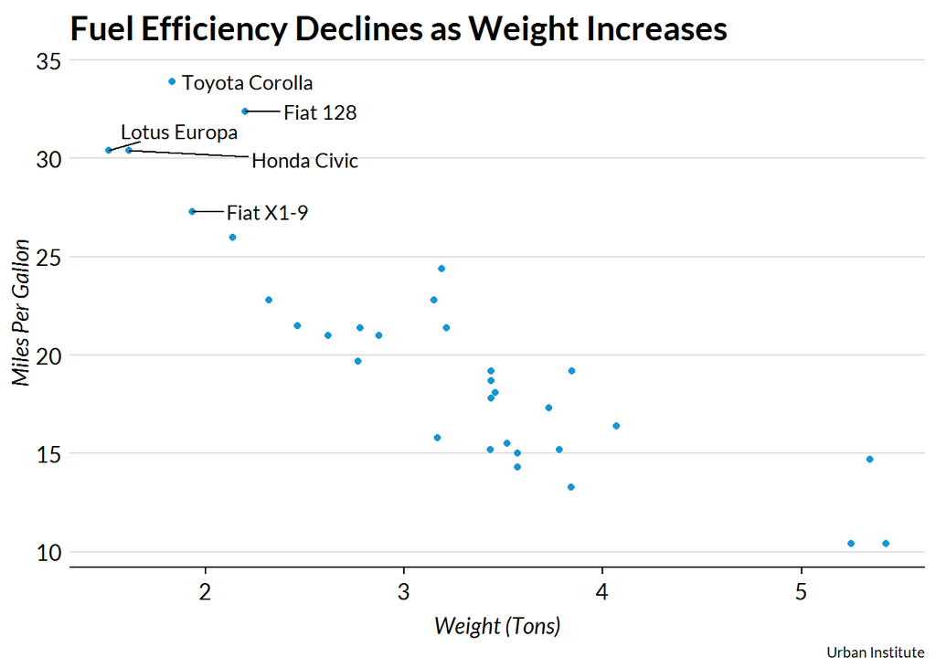

```r
library(ggrepel)

labels <- mtcars %>%
    rownames_to_column("model") %>%
    top_n(5, mpg)

mtcars %>%
    ggplot(mapping = aes(x = wt, y = mpg)) +
        geom_point() +
        geom_text_repel(data = labels,
                        mapping = aes(label = model),
                        nudge_x = 0.38) +
      labs(title = "Fuel Efficiency Declines as Weight Increases",
       caption = "Urban Institute",
       x = "Weight (Tons)",
       y = "Miles Per Gallon")
```

### annotate()

`annotate()` doesn’t use data frames. Instead, it takes values for `x =` and `y =`. It can add text, rectangles, segments, and pointrange.

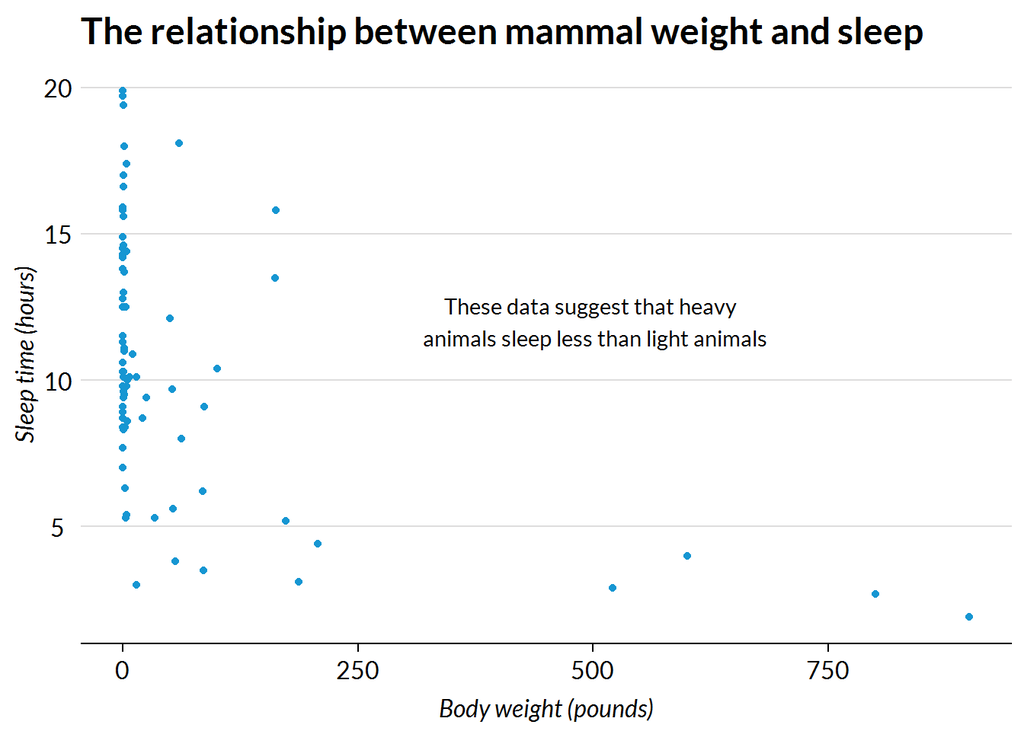

```r
msleep %>%
  filter(bodywt < 1000) %>%
  ggplot(aes(bodywt, sleep_total)) +
  geom_point() +
  annotate("text", x = 500, y = 12, label = "These data suggest that heavy \n animals sleep less than light animals") +
  labs(title = "The relationship between mammal weight and sleep",
       x = "Body weight (pounds)",
       y = "Sleep time (hours)")
```

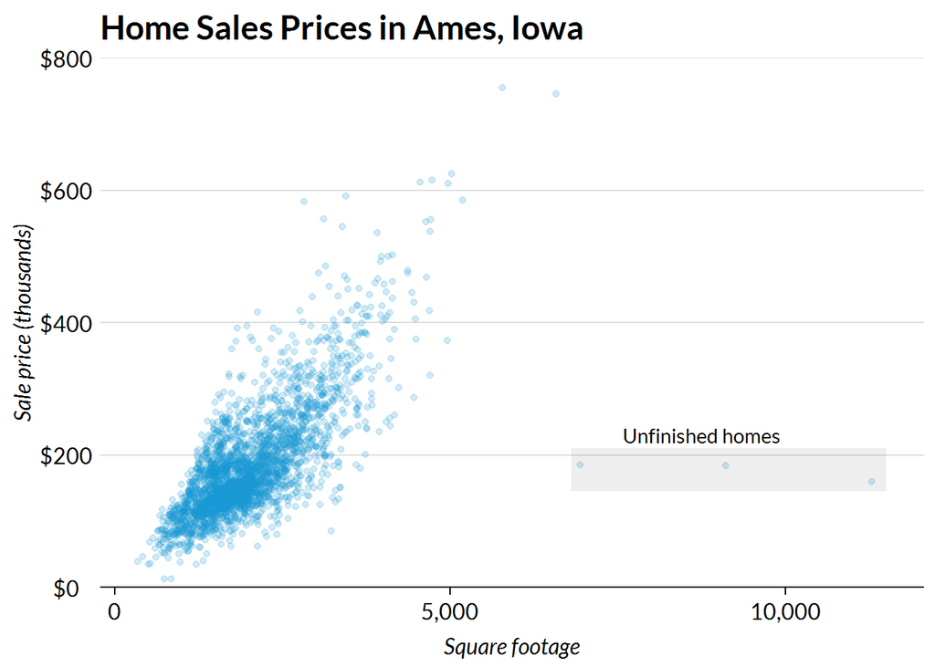

```r
library(AmesHousing)

ames <- make_ames()

ames %>%
  mutate(square_footage = Total_Bsmt_SF - Bsmt_Unf_SF + First_Flr_SF + Second_Flr_SF) %>%
  mutate(Sale_Price = Sale_Price / 1000) %>%
  ggplot(aes(square_footage, Sale_Price)) +
  geom_point(alpha = 0.2) +
  scale_y_continuous(expand = c(0, 0),
                     limits = c(0, 800),
                     labels = scales::dollar) +
  scale_x_continuous(labels = scales::comma,
                     breaks = c(0, 5000, 10000)) +
  labs(title = "Home Sales Prices in Ames, Iowa",
       x = "Square footage",
       y = "Sale price (thousands)") +
  annotate("rect", xmin = 6800, xmax = 11500, ymin = 145, ymax = 210, alpha = 0.1) +
  annotate("text", x = 8750, y = 230, label = "Unfinished homes")
```

## Layered Geoms

Geoms can be layered in `ggplot2`. This is useful for design and analysis.

It is often useful to add points to line plots with a small number of values across the x-axis. This example from [R for Data Science](http://r4ds.had.co.nz/tidy-data.html) shows how changing the line to grey can be appealing.

### Design

#### Before

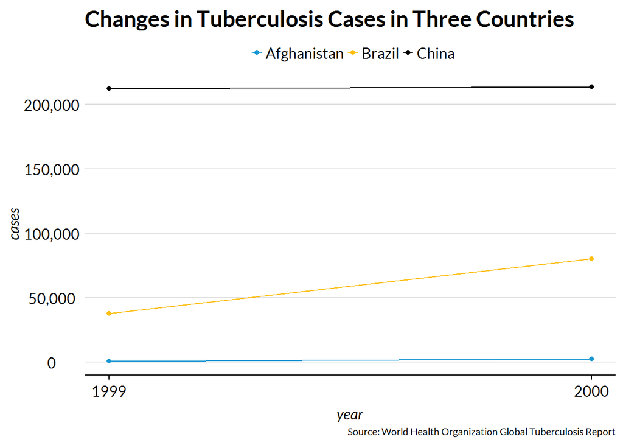

```r
table1 %>%
    ggplot(aes(x = year, y = cases)) +
        geom_line(aes(color = country)) +
        geom_point(aes(color = country)) +
        scale_y_continuous(labels = scales::comma) +
        scale_x_continuous(breaks = c(1999, 2000)) +
        labs(title = "Changes in Tuberculosis Cases in Three Countries",
                     caption = "Source: World Health Organization Global Tuberculosis Report")
```

#### After

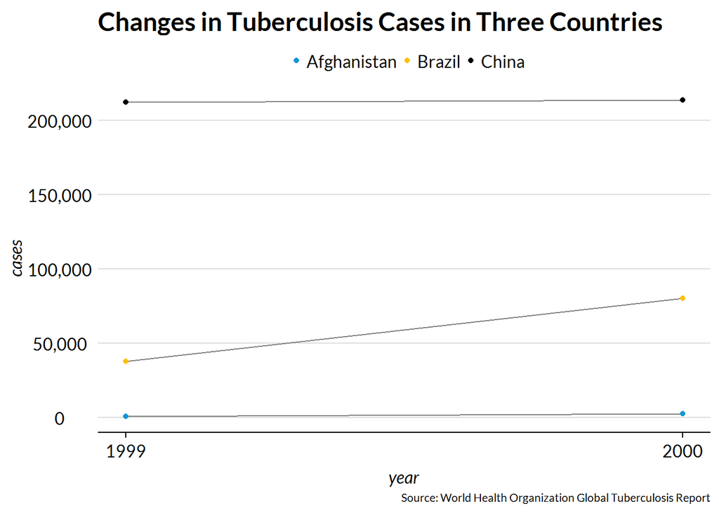

```r
table1 %>%
    ggplot(aes(year, cases)) +
        geom_line(aes(group = country), color = "grey50") +
        geom_point(aes(color = country)) +
        scale_y_continuous(labels = scales::comma) +
        scale_x_continuous(breaks = c(1999, 2000)) +
        labs(title = "Changes in Tuberculosis Cases in Three Countries",
                     caption = "Source: World Health Organization Global Tuberculosis Report")
```

Layering geoms is also useful for adding trend lines and centroids to scatter plots.

```r
# Simple line
# Regression model
# Centroids
```

### Centroids

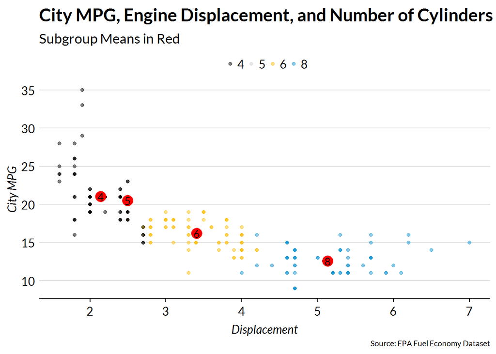

```r
mpg_summary <- mpg %>%
    group_by(cyl) %>%
    summarize(displ = mean(displ), cty = mean(cty))

mpg %>%
    ggplot() +
        geom_point(aes(x = displ, y = cty, color = factor(cyl)), alpha = 0.5) +
        geom_point(data = mpg_summary, aes(x = displ, y = cty), size = 5, color = "red") +
        geom_text(data = mpg_summary, aes(x = displ, y = cty, label = cyl)) +
        labs(title = "City MPG, Engine Displacement, and Number of Cylinders",
                 subtitle = "Subgroup Means in Red",
                 caption = "Source: EPA Fuel Economy Dataset",
                 x = "Displacement",
                 y = "City MPG")
```

## Saving Plots

`ggsave()` exports ggplot2 plots. The function can be used in two ways. If `plot =` isn’t specified in the function call, then `ggsave()` automatically saves the plot that was last displayed in the Viewer window. Second, if `plot =` is specified, then `ggsave()` saves the specified plot. `ggsave()` guesses the type of graphics device to use in export (.png, .pdf, .svg, etc.) from the file extension in the filename.

```r
mtcars %>%
  ggplot(aes(x = wt, y = mpg)) +
  geom_point()

ggsave(filename = "cars.png")

plot2 <- mtcars %>%
  ggplot(aes(x = wt, y = mpg)) +
  geom_point()

ggsave(filename = "cars.png", plot = plot2)
```

Exported plots rarely look identical to the plots that show up in the Viewer window in RStudio because the overall size and aspect ratio of the Viewer is often different than the defaults for `ggsave()`. Specific sizes, aspect ratios, and resolutions can be controlled with arguments in `ggsave()`. RStudio has a useful [cheatsheet](https://www.rstudio.com/resources/cheatsheets/) called “How Big is Your Graph?” that should help with choosing the best size, aspect ratio, and resolution.

In general, .svg files appear crisper than .png or .pdf files. However, .png and .pdf are more stable in web browsers.

## Bibliography and Session Information

*Note:* Examples present in [this document](https://awunderground.github.io/ggplot2-themes/) by Aaron Williams were created during personal time.

Bob Rudis and Dave Gandy (2017). waffle: Create Waffle Chart Visualizations in R. R package version 0.7.0. https://CRAN.R-project.org/package=waffle

Chester Ismay and Jennifer Chunn (2017). fivethirtyeight: Data and Code Behind the Stories and Interactives at ‘FiveThirtyEight’. R package version 0.3.0. https://CRAN.R-project.org/package=fivethirtyeight

Hadley Wickham. ggplot2: Elegant Graphics for Data Analysis. Springer-Verlag New York, 2009.

Hadley Wickham (2017). tidyverse: Easily Install and Load the ‘Tidyverse’. R package version 1.2.1. https://CRAN.R-project.org/package=tidyverse

Hadley Wickham (2017). forcats: Tools for Working with Categorical Variables (Factors). R package version 0.2.0. https://CRAN.R-project.org/package=forcats

Jennifer Bryan (2017). gapminder: Data from Gapminder. R package version 0.3.0. https://CRAN.R-project.org/package=gapminder

Kamil Slowikowski (2017). ggrepel: Repulsive Text and Label Geoms for ‘ggplot2’. R package version 0.7.0. https://CRAN.R-project.org/package=ggrepel

Max Kuhn (2017). AmesHousing: The Ames Iowa Housing Data. R package version 0.0.3. https://CRAN.R-project.org/package=AmesHousing

Peter Kampstra (2008). Beanplot: A Boxplot Alternative for Visual Comparison of Distributions, Journal of Statistical Software, 2008. https://www.jstatsoft.org/article/view/v028c01

R Core Team (2017). R: A language and environment for statistical computing. R Foundation for Statistical Computing, Vienna, Austria. URL https://www.R-project.org/.

Winston Chang, (2014). extrafont: Tools for using fonts. R package version 0.17. https://CRAN.R-project.org/package=extrafont

Yihui Xie (2018). knitr: A General-Purpose Package for Dynamic Report Generation in R. R package version 1.19.

[^1]: Wickham, H., & Stryjewski, L. (2011). 40 years of boxplots.